# Heritability analysis of natural selection metrics

## 2.2 Running stratified LD score regression

Stratified LDSC (v 1.0.1) was used to test for heritability enrichment of each of the natural selection metrics. All natural selection metrics were provided by Pardiñas et al. and annotated to the ~9,997,000 SNPs present in the LDSC baseline model (v 2.2). As in Pardiñas et al., binary annotations were generated from the natural selection metrics, with cut-offs at the top 1-5% (with intervals of 1%) of the values of each metric in the full set of SNPs (which included only SNPs with a minor allele frequency > 5%). Annotations were then added individually to the baseline-LD model of 97 annotations provided by Hujoel et al. (v 2.2, GRCh37), comprising genome-wide annotations reflecting genetic and LD architecture (PMID: [30905396](https://pubmed.ncbi.nlm.nih.gov/30905396/)). HapMap Project Phase 3 (HapMap3) SNPs and 1000 Genomes Project Phase 3 European population SNPs were used for the regression and LD reference panels, respectively (PMID: [20811451](https://pubmed.ncbi.nlm.nih.gov/20811451/), [23128226](https://pubmed.ncbi.nlm.nih.gov/23128226/)). The MHC region was excluded from all analyses owing to the complex and long-range LD patterns in this region. For all stratified LDSC analyses, we report a two-tailed p-value (coefficient p-value) based on the coefficient z-score outputted by stratified LDSC. This tests whether the regression coefficient of the annotation category contributes (either through enrichment or depletion) to the trait heritability conditional upon the baseline-LD model.

# 3 Supplementary code

## 3.1 Munging summary statistics

```bash
nohup bash \
/home/rreynolds/misc_projects/als-neanderthal-analysis/scripts/01a_munge_sumstats.sh \
&>/home/rreynolds/misc_projects/als-neanderthal-analysis/logs/01a_munge_sumstats.log&
```

## 3.2 Generating annotations

```bash
# Have to navigate to root project folder for script to work (as it uses here package)
cd /home/rreynolds/misc_projects/als-neanderthal-analysis

nohup Rscript \
/home/rreynolds/misc_projects/als-neanderthal-analysis/scripts/01b_generate_binary_annot.R \
&>/home/rreynolds/misc_projects/als-neanderthal-analysis/logs/01b_generate_binary_annot.log&
```

## 3.3 Running stratified LDSC

```bash
# Navigate to annotation folder
cd /home/rreynolds/misc_projects/als-neanderthal-analysis/raw_data/01_annotations/ldsc_annotations/

nohup Rscript \
/home/rreynolds/misc_projects/als-neanderthal-analysis/scripts/01c_run_ldsc.R \
&>/home/rreynolds/misc_projects/als-neanderthal-analysis/logs/01c_run_ldsc.log&
```

## 3.4 Tidy results

```r
source(here::here("scripts", "01d_tidy_results.R"))
```

## 3.5 Load files and results

```r
metric_df <-
  list.files(
    path = here::here("raw_data", "01_annotations", "positive_selection"),
    pattern = "\\.annot",
    full.names = T
  ) %>%
  lapply(
    .,
    readr::read_table
  ) %>%
  qdapTools::list_df2df(col1 = "list_name") %>%
  dplyr::select(-list_name) %>%
  dplyr::rename(XPEHH = XPEEH)

metric_df_top <-
  readRDS(
    here::here("raw_data", "01_annotations", "positive_selection_top_n.rds")
  ) %>%
  dplyr::mutate(
    selection_metric =
      case_when(
        selection_metric == "XPEEH" ~ "XPEHH",
        TRUE ~ selection_metric
      ),
    joint_name =
      case_when(
        str_detect(joint_name, "XPEEH") ~ str_replace(joint_name, "XPEEH", "XPEHH"),
        TRUE ~ joint_name
      )
  )

results <-
  read_delim(
    here::here("results", "01_annotations", "ldsc_summary.txt")
  ) %>%
  dplyr::group_by(GWAS) %>%
  dplyr::mutate(
    Z_score_FDR =
      p.adjust(
        p = Z_score_P,
        method = "fdr"
        )
  )

results_w_baseline <-
  read_delim(
    here::here("results", "01_annotations", "ldsc_summary_w_baseline_annot.txt")
  ) %>%
  dplyr::group_by(GWAS, Category) %>%
  dplyr::mutate(
    Z_score_FDR =
      p.adjust(
        p = Z_score_P,
        method = "fdr"
        )
  )
```

# 4 Results

## 4.1 Distribution of natural selection metrics

### 4.1.2 Table(s)

```r
metric_df %>%
  tidyr::pivot_longer(
    cols = IHS:LA,
    names_to = "selection_metric",
    values_to = "value"
  ) %>%
  dplyr::group_by(selection_metric) %>%
  dplyr::summarise(
    median = median(value),
    mean = mean(value),
    sd = sd(value),
    min = min(value),
    max = max(value)
  )
```

| selection_metric | median | mean | sd | min | max |
| --- | --- | --- | --- | --- | --- |
| CLR | 0.003528784 | 5.33561587 | 57.94790029 | 0.000000e+00 | 3928.827457 |
| CMS | 0.000000000 | 0.09960384 | 0.70421744 | 0.000000e+00 | 36.208358 |
| IHS | 0.600780068 | 0.74125252 | 0.61690277 | 5.666667e-08 | 10.531400 |
| LA | 0.012000000 | 0.02847366 | 0.04341009 | 0.000000e+00 | 0.713000 |
| XPEHH | 2.702900732 | 2.74495712 | 0.64227777 | -2.016156e-01 | 7.864937 |

### 4.1.3 Figures

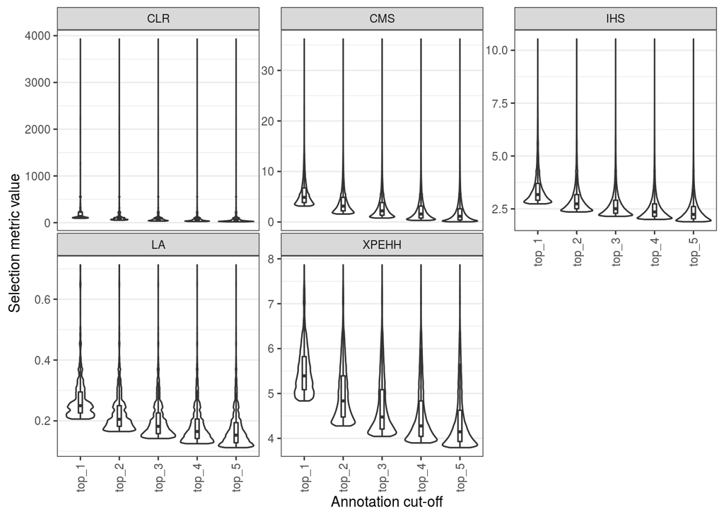

```r
metric_df_top %>%
  ggplot(
    aes(
      x = cutoff,
      y = value
        )
  ) +
  geom_violin() +
  geom_boxplot(width = 0.1, outlier.alpha = 0) +
  facet_wrap(vars(selection_metric), scales = "free_y") +
  labs(
    x = "Annotation cut-off",
    y = "Selection metric value"
  )
```

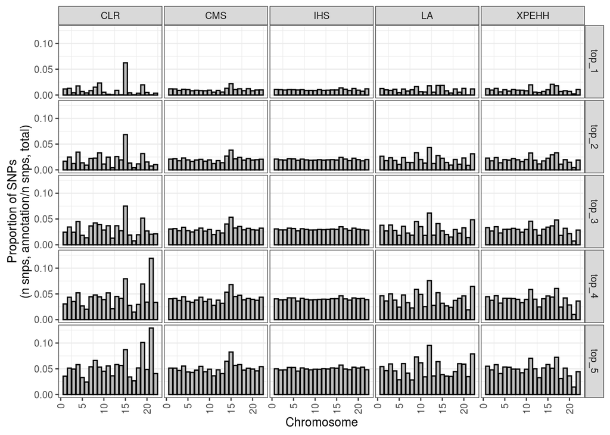

Figure 4.2: Number of SNPs in each annotation across each chromosome as a proportion of the total number of SNPs across each chromosome.

```r
metric_df_top %>%
  dplyr::group_by(cutoff, selection_metric, CHR) %>%
  dplyr::summarise(n_snps = n()) %>%
  dplyr::inner_join(
    metric_df %>%
      dplyr::group_by(CHR) %>%
      dplyr::summarise(total_snps = n())
  ) %>%
  dplyr::mutate(
    prop_snps = n_snps/total_snps
  ) %>%
  ggplot(
    aes(
      x = CHR,
      y = prop_snps
      )
    ) +
  geom_col(colour = "black", fill = "grey") +
  facet_grid(
    cols = vars(selection_metric),
    rows = vars(cutoff)
  ) +
  labs(
    x = "Chromosome",
    y = "Proportion of SNPs\n(n snps, annotation/n snps, total)"
  )
```

## 4.2 Results of stratified LDSC: annotations of interest

### 4.2.1 Text

- FDR multiple test correction was applied across each GWAS, correcting for the number of annotations run (i.e. 5 cut-offs x 5 selection metrics).
- Using FDR-corrected results, a significant depletion was observed for:
  - AD $h^2_{SNP}$ using the top 2%, 3% and 4% CLR statistic.
  - PD $h^2_{SNP}$ using the top 1%, 2%, 3%, and 4% of XP-EHH statistic, suggesting that SNPs under positive selection are depleted for association with PD.

```r
print("Results (FDR < 0.05):")
```

```
## [1] "Results (FDR < 0.05):"
```

```r
results %>%
  dplyr::filter(Z_score_FDR < 0.05) %>%
  dplyr::arrange(GWAS, selection_metrics, cutoff) %>%
  dplyr::select(
    GWAS, cutoff, selection_metrics, Enrichment, Coefficient, Z_score_P, Z_score_FDR
    )
```

| GWAS | cutoff | selection_metrics | Enrichment | Coefficient | Z_score_P | Z_score_FDR |
| --- | --- | --- | --- | --- | --- | --- |
| AD2019 | Top 2% | CLR | -0.4646668 | -2.121251e-09 | 0.002728212 | 0.02303395 |
| AD2019 | Top 3% | CLR | -0.3546886 | -2.197372e-09 | 0.002263730 | 0.02303395 |
| AD2019 | Top 4% | CLR | -0.3050291 | -2.237035e-09 | 0.002764074 | 0.02303395 |
| PD2019.meta5.ex23andMe | Top 1% | XPEHH | -2.5015771 | -1.119685e-08 | 0.001387439 | 0.03468598 |
| PD2019.meta5.ex23andMe | Top 2% | XPEHH | -1.2356560 | -7.780128e-09 | 0.006549868 | 0.04259209 |
| PD2019.meta5.ex23andMe | Top 3% | XPEHH | -0.8062073 | -6.772391e-09 | 0.005372526 | 0.04259209 |
| PD2019.meta5.ex23andMe | Top 4% | XPEHH | -0.4829906 | -5.890105e-09 | 0.006814734 | 0.04259209 |

- While no annotations were significantly enriched/depleted when using the ALS GWAS, there were nominal results (co-efficient p-value < 0.05), including:
  - An enrichment ALS $h^2_{SNP}$ using the top 1% iHS statistic and the top 2% of the XP-EHH statistic. Notably, both statistics are variants on EHH and are thought to be complementary in terms of their scope: *"whereas iHS has more power to detect incomplete sweeps, XP-EHH is useful when the sweep is near fixation within one population"* (PMID: [24274750](https://pubmed.ncbi.nlm.nih.gov/24274750/)). Important to remember, however, that XP-EHH is a cross-population measure!
  - A depletion of ALS $h^2_{SNP}$ using the top 1%, 2% and 3% CLR.
  - Confusingly, iHS, XP-EHH and CLR are all metrics of positive selection, thus an enrichment and depletion appears counter-intuitive. However, it is important to remember that these metrics detect particular selective processes that act on a particular timeframe. As stated in Pardiñas et al. 2018, iHS is *"better powered to detect recent selective sweeps"*, while CLR *"incorporates information about the spatial variability of genomic variability and corrects explicitly for evidence of background selection, thus being able to detect signals from 60,000 to 240,000 years ago"*. Thus, it is possible that SNPs from recent selective sweeps are enriched for association with ALS, while those SNPs from older selective sweeps are depleted for association with ALS.

```r
print("Results (p < 0.05):")
```

```
## [1] "Results (p < 0.05):"
```

```r
results %>%
  dplyr::filter(Z_score_P < 0.05) %>%
  dplyr::arrange(GWAS, selection_metrics, cutoff) %>%
  dplyr::select(
    GWAS, cutoff, selection_metrics, Enrichment, Coefficient, Z_score_P, Z_score_FDR
    )
```

| GWAS | cutoff | selection_metrics | Enrichment | Coefficient | Z_score_P | Z_score_FDR |
| --- | --- | --- | --- | --- | --- | --- |
| AD2019 | Top 2% | CLR | -0.46466684 | -2.121251e-09 | 0.002728212 | 0.02303395 |
| AD2019 | Top 3% | CLR | -0.35468859 | -2.197372e-09 | 0.002263730 | 0.02303395 |
| AD2019 | Top 4% | CLR | -0.30502911 | -2.237035e-09 | 0.002764074 | 0.02303395 |
| AD2019 | Top 5% | CLR | -0.11952320 | -1.905220e-09 | 0.008566935 | 0.05354334 |
| ALS2021.EUR | Top 1% | CLR | -0.79521475 | -1.114539e-08 | 0.016623263 | 0.16046943 |
| ALS2021.EUR | Top 2% | CLR | -0.58062972 | -1.010677e-08 | 0.025675109 | 0.16046943 |
| ALS2021.EUR | Top 3% | CLR | -0.46846816 | -1.013681e-08 | 0.012701430 | 0.16046943 |
| ALS2021.EUR | Top 1% | IHS | 6.77196771 | 6.209452e-08 | 0.021111298 | 0.16046943 |
| ALS2021.EUR | Top 2% | XPEHH | 3.00408582 | 2.888262e-08 | 0.041550243 | 0.20775122 |
| PD2019.meta5.ex23andMe | Top 5% | IHS | -0.31109179 | -4.312675e-09 | 0.045704197 | 0.16322928 |

[output cut: 6 more lines]

### 4.2.2 Table(s)

```r
print("All results:")
```

```
## [1] "All results:"
```

```r
results %>%
  dplyr::group_by(GWAS) %>%
  dplyr::select(-contains("SE"), -contains("log")) %>%
  DT::datatable(
    rownames = FALSE,
    options = list(scrollX = TRUE),
    class = 'white-space: nowrap'
  )
```

| GWAS | cutoff | Prop._SNPs | Prop._h2 | Prop._h2_std_error | Enrichment | Enrichment_std_error | Enrichment_p | Coefficient | Coefficient_std_error | Coefficient_z-score | Z_score_P | Z_score_FDR |
| --- | --- | --- | --- | --- | --- | --- | --- | --- | --- | --- | --- | --- |
| AD2019 | Top 1% | 0.00799609606119 | -0.00229968889921 | 0.00282474344873 | -0.287601459714 | 0.353265321866 | 0.00026276465990583 | -1.48052839863e-09 | 9.08612360895e-10 | -1.62943898009 | 0.1032201225732 | 0.405512845618418 |
| AD2019 | Top 1% | 0.00866542898789 | 0.00853701405276 | 0.0105391125451 | 0.985180775781 | 1.21622513552 | 0.990286009389119 | -3.70572935372e-10 | 3.30349002936e-09 | -0.11217619308 | 0.910683705181684 | 0.910683705181684 |
| AD2019 | Top 1% | 0.0113685945971 | -0.0212840979099 | 0.0243515154304 | -1.87218373635 | 2.14199875124 | 0.185412662623881 | -7.29321027458e-09 | 5.90121810634e-09 | -1.23588217604 | 0.216502363284875 | 0.520473437307806 |
| AD2019 | Top 1% | 0.0111318956599 | 0.00649428781169 | 0.00684249483682 | 0.583394599636 | 0.614674719013 | 0.500547330686165 | -1.49555633e-09 | 1.76865901165e-09 | -0.84558771371 | 0.397782781925568 | 0.63497534077209 |
| AD2019 | Top 1% | 0.0091354718101 | -0.00698254583635 | 0.0104115983706 | -0.764333356995 | 1.13968917939 | 0.121840005509611 | -3.57689877979e-09 | 3.40028042235e-09 | -1.05194229166 | 0.292826026955575 | 0.563126974914567 |
| AD2019 | Top 2% | 0.0158392017391 | -0.00735995181753 | 0.00485251854032 | -0.464666839829 | 0.306361306601 | 3.82613149869517e-07 | -2.12125136724e-09 | 7.0783657823e-10 | -2.99680947903 | 0.00272821159936071 | 0.0230339501796225 |
| AD2019 | Top 2% | 0.0170143087946 | 0.0115885684388 | 0.0142802161307 | 0.681107212677 | 0.839306274679 | 0.704635420890283 | -1.24476254202e-09 | 2.31367042723e-09 | -0.538003393817 | 0.590574705571311 | 0.703065125680132 |
| AD2019 | Top 2% | 0.0224921026264 | -0.01642669564 | 0.0281163120096 | -0.730331704106 | 1.25005262855 | 0.176310648828552 | -4.17124086748e-09 | 3.46760392851e-09 | -1.2029173324 | 0.229008312415435 | 0.520473437307806 |
| AD2019 | Top 2% | 0.0226034903615 | 0.0124601720723 | 0.01051525278 | 0.551249911982 | 0.465204825088 | 0.331001235490514 | -1.50216536122e-09 | 1.33694403452e-09 | -1.12358133357 | 0.261190678625614 | 0.544147247136696 |
| AD2019 | Top 2% | 0.0185626654146 | -0.0139473346901 | 0.0160274344277 | -0.751364870216 | 0.863423116767 | 0.0409611913667126 | -3.96891093314e-09 | 2.56578684077e-09 | -1.54685918178 | 0.121897205632511 | 0.405512845618418 |

[output cut: 65 more lines]

## 4.3 Results of stratified LDSC: baseline annotations

### 4.3.1 Text

- FDR multiple test correction was applied across each GWAS and Category, correcting for the number of annotations of interest run (i.e. 5 cut-offs x 5 selection metrics). This is comparable to the strategy applied for the annotations of interest, but is probably not sufficiently stringent, given the number of baseline annotations.
- The same baseline annotations are enriched/depleted across different GWASs in spite of changing selection metrics/cut-offs. Thus, we can average (mean) across enrichment and coefficient estimates to get an idea of how these baseline annotations are contributing to trait heritability, depending on the trait.

```r
print("Results averaged across 5 cut-offs x 5 selection metrics (FDR < 0.05):")
```

```
## [1] "Results averaged across 5 cut-offs x 5 selection metrics (FDR < 0.05):"
```

```r
results_w_baseline %>%
  dplyr::filter(
    Category != "L2_0", # exclude selection metrics
    Z_score_FDR < 0.05
    ) %>%
  dplyr::group_by(GWAS, Category) %>%
  dplyr::summarise(
    n = n(),
    mean_prop_h2 = mean(Prop._h2),
    mean_enrichment = mean(Enrichment),
    sd_enrichment = sd(Enrichment),
    mean_coefficient = mean(Coefficient),
    sd_coefficient = sd(Coefficient),
    mean_z_score_p = mean(Z_score_P),
    sd_z_score_p = sd(Z_score_P)
  )
```

| GWAS | Category | n | mean_prop_h2 | mean_enrichment | sd_enrichment | mean_coefficient | sd_coefficient | mean_z_score_p | sd_z_score_p |
| --- | --- | --- | --- | --- | --- | --- | --- | --- | --- |
| AD2019 | BLUEPRINT_H3K27acQTL_MaxCPPL2_1 | 25 | 0.19066790 | 11.5238183 | 0.082596522 | 4.869870e-08 | 6.762491e-11 | 0.033038417 | 1.663833e-04 |
| AD2019 | Coding_UCSCL2_1 | 25 | 0.13480010 | 9.4535927 | 0.049475718 | 3.769060e-08 | 2.089207e-10 | 0.023792227 | 8.190863e-04 |
| AD2019 | Conserved_Mammal_phastCons46way.flanking.500L2_1 | 25 | 0.75102787 | 2.3633568 | 0.013716257 | 1.638236e-08 | 2.632842e-10 | 0.036452551 | 2.410254e-03 |
| AD2019 | GTEx_eQTL_MaxCPPL2_1 | 25 | 0.20849794 | 20.1634121 | 0.128194130 | 8.180143e-08 | 2.642280e-10 | 0.001998270 | 7.793231e-05 |
| AD2019 | H3K27ac_HniszL2_1 | 25 | 0.89497955 | 2.3004596 | 0.007582869 | 4.084338e-09 | 1.135028e-11 | 0.044867999 | 5.095318e-04 |
| AD2019 | MAFbin4L2_1 | 25 | 0.16599397 | 1.6484715 | 0.013106835 | 2.510145e-09 | 5.326525e-11 | 0.030812467 | 5.837797e-03 |
| AD2019 | Transcr_Hoffman.flanking.500L2_1 | 25 | 0.61512469 | 1.4761437 | 0.004772082 | 6.111124e-09 | 5.621527e-11 | 0.002749770 | 2.643194e-04 |
| ALS2021.EUR | Conserved_Vertebrate_phastCons46wayL2_1 | 25 | 0.13147354 | 4.4664118 | 0.061128157 | -1.833633e-07 | 9.888063e-10 | 0.001865608 | 1.419946e-04 |
| ALS2021.EUR | GERP.NSL2_1 | 25 | 3.73399075 | 2.1394350 | 0.025914635 | 7.793685e-09 | 3.187128e-10 | 0.018983795 | 4.853321e-03 |
| ALS2021.EUR | H3K27ac_Hnisz.flanking.500L2_1 | 25 | 0.31838391 | 10.1346551 | 0.109197773 | 9.654584e-08 | 3.957775e-10 | 0.009864002 | 2.753526e-04 |

[output cut: 4 more lines]

### 4.3.2 Table(s)

```r
print("Results (FDR < 0.05):")
```

```
## [1] "Results (FDR < 0.05):"
```

```r
results_w_baseline %>%
  dplyr::filter(Z_score_FDR < 0.05) %>%
  dplyr::select(-contains("SE"), -contains("log")) %>%
  DT::datatable(
    rownames = FALSE,
    options = list(scrollX = TRUE),
    class = 'white-space: nowrap'
  )
```

| GWAS | cutoff | Category | Prop._SNPs | Prop._h2 | Prop._h2_std_error | Enrichment | Enrichment_std_error | Enrichment_p | Coefficient | Coefficient_std_error | Coefficient_z-score | Z_score_P | Z_score_FDR |
| --- | --- | --- | --- | --- | --- | --- | --- | --- | --- | --- | --- | --- | --- |
| AD2019 | Top 1% | Coding_UCSCL2_1 | 0.0142591398753 | 0.135879788303 | 0.0690861559274 | 9.52931169002 | 4.84504370751 | 0.0742662173543705 | 3.79158915864e-08 | 1.66575772734e-08 | 2.27619484899 | 0.0228343500856543 | 0.0247250253188376 |
| AD2019 | Top 1% | H3K27ac_HniszL2_1 | 0.389043808427 | 0.895193954697 | 0.147515831784 | 2.30101067105 | 0.379175374569 | 0.00064631565788675 | 4.09073153904e-09 | 2.0363225735e-09 | 2.00888188947 | 0.0445496610031081 | 0.0457271843102441 |
| AD2019 | Top 1% | Transcr_Hoffman.flanking.500L2_1 | 0.416710575913 | 0.617210816927 | 0.168366066761 | 1.48114987381 | 0.40403598203 | 0.242904717765617 | 6.15795862941e-09 | 2.03828031856e-09 | 3.02115394695 | 0.00251813295554356 | 0.00337193459634265 |
| AD2019 | Top 1% | MAFbin4L2_1 | 0.100695686862 | 0.166641258963 | 0.0387272105526 | 1.65489967004 | 0.384596518077 | 0.0752836751915962 | 2.54227816633e-09 | 1.15268514525e-09 | 2.20552696182 | 0.0274171379685815 | 0.0370459468485279 |
| AD2019 | Top 1% | GTEx_eQTL_MaxCPPL2_1 | 0.0103404094611 | 0.208454068736 | 0.060423828354 | 20.1591696653 | 5.84346573325 | 0.00057595253162736 | 8.18472419802e-08 | 2.64281025468e-08 | 3.09697761446 | 0.00195504636864759 | 0.00209000927832596 |
| AD2019 | Top 1% | BLUEPRINT_H3K27acQTL_MaxCPPL2_1 | 0.0165455490697 | 0.190880819535 | 0.0628719790888 | 11.5366869199 | 3.79993307105 | 0.00355039434510301 | 4.87839791552e-08 | 2.28542291244e-08 | 2.13457119423 | 0.0327960524939313 | 0.0333546793374192 |
| AD2019 | Top 1% | Conserved_Mammal_phastCons46way.flanking.500L2_1 | 0.3177801498 | 0.748558697474 | 0.182902588393 | 2.3555867097 | 0.575563289613 | 0.013182168418078 | 1.62000145073e-08 | 7.79787016509e-09 | 2.07749220804 | 0.0377561536651857 | 0.0390892319991636 |
| AD2019 | Top 1% | Coding_UCSCL2_1 | 0.0142591398753 | 0.13505186065 | 0.0689844732343 | 9.47124874508 | 4.83791265374 | 0.076121883042477 | 3.76788422676e-08 | 1.6672000093e-08 | 2.2600073211 | 0.0238207964650952 | 0.0247250253188376 |
| AD2019 | Top 1% | H3K27ac_HniszL2_1 | 0.389043808427 | 0.895716017349 | 0.147259402778 | 2.3023525833 | 0.378516248268 | 0.00065077422685619 | 4.09445838914e-09 | 2.03700625295e-09 | 2.01003722163 | 0.0444272495263991 | 0.0457271843102441 |
| AD2019 | Top 1% | Transcr_Hoffman.flanking.500L2_1 | 0.416710575913 | 0.615445750293 | 0.168569782935 | 1.47691416025 | 0.404524849328 | 0.247793499674239 | 6.12838781484e-09 | 2.04036103751e-09 | 3.00358010282 | 0.0026682329868697 | 0.00337193459634265 |

[output cut: 345 more lines]

# 5 Session info

**Show/hide**